# Portfolio 1: Steve's Cycling Data Exploration and Analysis

Steve is just a regular and simple guy who lives in Sydney. He loves a lot of things and loves doing a lot of activities. Cycling is one of his favourite activities and he loves it because it makes him happy and healthy, and it can also be a challenging activity. This project goal is to explore Steve's cycling data and analize several interesting things about Steve's cycling habit.

## Libraries and Data Preparation

### Libraries

The libraries that are used for this project are listed below:

```python
import pandas as pd
import numpy as np
from matplotlib import pyplot as plt
from datetime import timedelta
import seaborn as sns
from scipy.stats import norm
import warnings
warnings.filterwarnings('ignore')

pd.options.display.float_format = '{:,.2f}'.format
%matplotlib inline
```

### Data Preparation

There are 2 datasets that are used in this project. The datasets are the following:

- Export of Steve's ride data from [Strava](https://strava.com/), an online social network site for cycling and other sports. The dataset contains Steve's cycling logs since the start of 2018 and contains summary data like distance and average speed. It was exported using the script `scripts/stravaget.py` which uses the stravalib module to read data. Some details of the fields exported by that script can be seen in [the documentation for stravalib](https://pythonhosted.org/stravalib/api.html#stravalib.model.Activity).
- Dataset from an application called [GoldenCheetah](https://www.goldencheetah.org/) which provides some analytics services over ride data. The dataset adds a lot of analysis of the power, speed and heart rate data in each ride. This data overlaps with the Strava data but doesn't include all of the same rides.

Basic exploration of the two datasets are below

```python
# Loading and exploring data from Strava
strava = pd.read_csv('data/Portfolio1files/strava_export.csv', index_col='date', parse_dates=True)
print('The strava data set number of rows and columns are', strava.shape)
display(strava.describe())
print('The strava columns are:')
display(set(strava.columns))
display(strava.sample(5))
```

```
The strava data set number of rows and columns are (268, 10)
```

|  | average_heartrate | average_temp | average_watts | distance | elapsed_time | kudos | moving_time |
| --- | --- | --- | --- | --- | --- | --- | --- |
| count | 232.00 | 204.00 | 254.00 | 268.00 | 268.00 | 268.00 | 268.00 |
| mean | 122.08 | 15.10 | 162.04 | 31.96 | 120.59 | 11.12 | 80.89 |
| std | 13.45 | 5.95 | 35.34 | 21.64 | 129.78 | 5.38 | 49.95 |
| min | 73.30 | 0.00 | 13.80 | 0.00 | 3.00 | 2.00 | 2.00 |
| 25% | 113.70 | 11.00 | 137.27 | 12.73 | 47.50 | 7.00 | 45.00 |
| 50% | 121.40 | 16.00 | 158.05 | 27.35 | 68.00 | 10.00 | 64.00 |
| 75% | 128.65 | 19.00 | 185.28 | 51.75 | 189.00 | 15.00 | 132.50 |
| max | 156.50 | 31.00 | 272.50 | 108.20 | 673.00 | 24.00 | 236.00 |

```
The strava columns are:
```

```
{'average_heartrate',
 'average_temp',
 'average_watts',
 'device_watts',
 'distance',
 'elapsed_time',
 'elevation_gain',
 'kudos',
 'moving_time',
 'workout_type'}
```

| date | average_heartrate | average_temp | average_watts | device_watts | distance | elapsed_time | elevation_gain | kudos | moving_time | workout_type |
| --- | --- | --- | --- | --- | --- | --- | --- | --- | --- | --- |
| 2018-03-31 19:56:13+00:00 | 119.20 | 19.00 | 147.50 | True | 81.80 | 247 | 930.00 m | 14 | 189 | Ride |
| 2018-12-12 19:20:20+00:00 | 131.90 | NaN | 176.90 | True | 25.70 | 61 | 0.00 m | 7 | 61 | Workout |
| 2019-05-25 22:05:48+00:00 | 131.70 | 10.00 | 219.50 | True | 10.00 | 17 | 26.00 m | 15 | 17 | Race |
| 2019-01-06 21:30:25+00:00 | 112.00 | NaN | 137.90 | False | 18.50 | 338 | 344.40 m | 8 | 60 | Ride |
| 2019-03-09 19:48:04+00:00 | 100.00 | 15.00 | 112.70 | True | 4.80 | 13 | 52.00 m | 3 | 13 | Ride |

```python
# Loading and exploring data from cheetah
cheetah = pd.read_csv('data/Portfolio1files/cheetah.csv', skipinitialspace=True)
print('The cheetah data set number of rows and columns are', cheetah.shape)
display(cheetah.describe())
print('The cheetah columns are', strava.shape)
display(cheetah.columns)
display(cheetah.sample(5))
```

```
The cheetah data set number of rows and columns are (251, 362)
```

|  | axPower | aPower Relative Intensity | aBikeScore | Skiba aVI | aPower Response Index | aIsoPower | aIF | aBikeStress | aVI | aPower Efficiency Factor | ... | Rest AVNN | Rest SDNN | Rest rMSSD | Rest PNN50 | Rest LF | Rest HF | HRV Recovery Points | NP | IF | TSS |
| --- | --- | --- | --- | --- | --- | --- | --- | --- | --- | --- | --- | --- | --- | --- | --- | --- | --- | --- | --- | --- | --- |
| count | 251.00 | 251.00 | 251.00 | 251.00 | 251.00 | 251.00 | 251.00 | 251.00 | 251.00 | 251.00 | ... | 251.00 | 251.00 | 251.00 | 251.00 | 251.00 | 251.00 | 251.00 | 251.00 | 251.00 | 251.00 |
| mean | 167.86 | 0.63 | 72.15 | 1.03 | 1.24 | 182.71 | 0.68 | 82.67 | 1.12 | 1.35 | ... | 0.00 | 0.00 | 0.00 | 0.00 | 0.00 | 0.00 | 0.00 | 182.24 | 0.68 | 82.11 |
| std | 84.13 | 0.31 | 65.38 | 0.50 | 0.76 | 90.96 | 0.34 | 74.77 | 0.56 | 0.83 | ... | 0.00 | 0.00 | 0.00 | 0.00 | 0.00 | 0.00 | 0.00 | 90.68 | 0.34 | 73.64 |
| min | 0.00 | 0.00 | 0.00 | 0.00 | 0.00 | 0.00 | 0.00 | 0.00 | 0.00 | 0.00 | ... | 0.00 | 0.00 | 0.00 | 0.00 | 0.00 | 0.00 | 0.00 | 0.00 | 0.00 | 0.00 |
| 25% | 166.61 | 0.62 | 21.14 | 1.09 | 0.00 | 181.61 | 0.68 | 23.48 | 1.13 | 0.00 | ... | 0.00 | 0.00 | 0.00 | 0.00 | 0.00 | 0.00 | 0.00 | 181.55 | 0.68 | 23.39 |
| 50% | 197.37 | 0.74 | 60.05 | 1.23 | 1.58 | 216.37 | 0.81 | 68.14 | 1.32 | 1.73 | ... | 0.00 | 0.00 | 0.00 | 0.00 | 0.00 | 0.00 | 0.00 | 215.51 | 0.80 | 67.97 |
| 75% | 218.02 | 0.81 | 118.65 | 1.31 | 1.75 | 235.43 | 0.88 | 142.82 | 1.45 | 1.88 | ... | 0.00 | 0.00 | 0.00 | 0.00 | 0.00 | 0.00 | 0.00 | 235.09 | 0.88 | 142.55 |
| max | 284.99 | 1.06 | 386.25 | 1.74 | 2.29 | 302.49 | 1.13 | 419.56 | 2.13 | 2.65 | ... | 0.00 | 0.00 | 0.00 | 0.00 | 0.00 | 0.00 | 0.00 | 302.40 | 1.13 | 412.07 |

8 rows × 359 columns

```
The cheetah columns are (268, 10)
```

```
Index(['date', 'time', 'filename', 'axPower', 'aPower Relative Intensity',
       'aBikeScore', 'Skiba aVI', 'aPower Response Index', 'aIsoPower', 'aIF',
       ...
       'Rest AVNN', 'Rest SDNN', 'Rest rMSSD', 'Rest PNN50', 'Rest LF',
       'Rest HF', 'HRV Recovery Points', 'NP', 'IF', 'TSS'],
      dtype='object', length=362)
```

|  | date | time | filename | axPower | aPower Relative Intensity | aBikeScore | Skiba aVI | aPower Response Index | aIsoPower | aIF | ... | Rest AVNN | Rest SDNN | Rest rMSSD | Rest PNN50 | Rest LF | Rest HF | HRV Recovery Points | NP | IF | TSS |
| --- | --- | --- | --- | --- | --- | --- | --- | --- | --- | --- | --- | --- | --- | --- | --- | --- | --- | --- | --- | --- | --- |
| 207 | 05/07/19 | 06:59:50 | 2019_05_07_06_59_50.json | 222.02 | 0.83 | 86.09 | 1.17 | 1.72 | 224.11 | 0.84 | ... | 0 | 0 | 0 | 0 | 0 | 0 | 0 | 224.11 | 0.84 | 87.72 |
| 84 | 10/09/18 | 06:31:47 | 2018_10_09_06_31_47.json | 140.23 | 0.52 | 13.75 | 1.04 | 1.39 | 140.59 | 0.52 | ... | 0 | 0 | 0 | 0 | 0 | 0 | 0 | 140.59 | 0.52 | 13.82 |
| 158 | 02/17/19 | 05:57:11 | 2019_02_17_05_57_11.json | 196.85 | 0.73 | 43.65 | 1.23 | 1.52 | 214.52 | 0.80 | ... | 0 | 0 | 0 | 0 | 0 | 0 | 0 | 214.05 | 0.80 | 50.48 |
| 185 | 04/10/19 | 07:04:31 | 2019_04_10_07_04_31.json | 232.16 | 0.87 | 31.00 | 1.23 | 1.94 | 234.05 | 0.87 | ... | 0 | 0 | 0 | 0 | 0 | 0 | 0 | 234.05 | 0.87 | 31.50 |
| 221 | 05/28/19 | 06:50:01 | 2019_05_28_06_50_01.json | 206.71 | 0.77 | 29.89 | 1.19 | 1.83 | 208.36 | 0.78 | ... | 0 | 0 | 0 | 0 | 0 | 0 | 0 | 208.36 | 0.78 | 30.37 |

5 rows × 362 columns

The dataset from cheetah application is more detailed and contains a lot more features than the dataset from strava. There are 10 features in strava dataset and 362 features in cheetah dataset.

Here are definitions of some of the more important fields in the data. Capitalised fields come from the GoldenCheetah data while lowercase_fields come from Strava. There are many cases where fields are duplicated and in this case the values should be the same, although there is room for variation as the algorithm used to calculate them could be different in each case.

- Duration - overall duration of the ride, should be same as elapsed_time
- Time Moving - time spent moving (not resting or waiting at lights), should be the same as moving_time
- Elevation Gain - metres climbed over the ride
- Average Speed - over the ride
- Average Power - average power in watts as measured by a power meter, relates to how much effort is being put in to the ride, should be the same as * average_watts' from Strava
- Nonzero Average Power - same as Average Power but excludes times when power is zero from the average
- Average Heart Rate - should be the same as average_heartrate
- Average Cadence - cadence is the rotations per minute of the pedals
- Average Temp - temperature in the environment as measured by the bike computer (should be same as average_temp)
- VAM - average ascent speed - speed up hills
- Calories (HR) - Calorie expendature as estimated from heart rate data
- 1 sec Peak Power - this and other 'Peak Power' measures give the maximum power output in the ride over this time period. Will be higher for shorter periods. High values in short periods would come from a very 'punchy' ride with sprints for example.
- 1 min Peak Hr - a similar measure relating to Heart Rate
- NP - Normalised Power, a smoothed average power measurement, generally higher than Average Power
- TSS - Training Stress Score, a measure of how hard a ride this was
- device_watts - True if the power (watts) measures were from a power meter, False if they were estimated
- distance - distance travelled in Km
- kudos - likes from other Strava users (social network)
- workout_type - one of 'Race', 'Workout' or 'Ride'

Some of the GoldenCheetah parameters are defined [in their documentation](https://github.com/GoldenCheetah/GoldenCheetah/wiki/UG_Glossary).

The two datasets contain different number of rows and the some rows will be discarded when the datasets are joined. The date feature is assigned as index of the dataset and the date timezone in each dataset must be localized before joining the datasets. The localisation is below:

```python
# Localising strava and cheetah data timezone
strava.index = strava.index.tz_convert('Australia/Sydney')
cheetah.index = pd.to_datetime(cheetah['date'] + ' ' + cheetah['time'])
cheetah.index = cheetah.index.tz_localize('Australia/Sydney')

display(strava.iloc[34:39])
display(cheetah.iloc[17:22])
```

| date | average_heartrate | average_temp | average_watts | device_watts | distance | elapsed_time | elevation_gain | kudos | moving_time | workout_type |
| --- | --- | --- | --- | --- | --- | --- | --- | --- | --- | --- |
| 2018-03-01 07:10:03+11:00 | 121.80 | 19.00 | 141.20 | True | 51.00 | 160 | 947.00 m | 8 | 145 | Ride |
| 2018-03-01 18:07:22+11:00 | NaN | 20.00 | 124.10 | True | 11.50 | 39 | 242.00 m | 7 | 36 | Ride |
| 2018-03-03 06:19:12+11:00 | 123.80 | 18.00 | 175.90 | True | 60.10 | 195 | 615.00 m | 14 | 141 | Ride |
| 2018-03-04 06:02:13+11:00 | 117.20 | 17.00 | 177.30 | True | 20.60 | 56 | 222.00 m | 10 | 52 | Ride |
| 2018-03-04 07:02:23+11:00 | 143.00 | 18.00 | 217.30 | True | 15.50 | 32 | 175.00 m | 15 | 28 | Race |

|  | date | time | filename | axPower | aPower Relative Intensity | aBikeScore | Skiba aVI | aPower Response Index | aIsoPower | aIF | ... | Rest AVNN | Rest SDNN | Rest rMSSD | Rest PNN50 | Rest LF | Rest HF | HRV Recovery Points | NP | IF | TSS |
| --- | --- | --- | --- | --- | --- | --- | --- | --- | --- | --- | --- | --- | --- | --- | --- | --- | --- | --- | --- | --- | --- |
| 2018-03-01 07:10:03+11:00 | 03/01/18 | 07:10:03 | 2018_03_01_07_10_03.json | 200.42 | 0.75 | 148.53 | 1.44 | 1.65 | 216.89 | 0.81 | ... | 0 | 0 | 0 | 0 | 0 | 0 | 0 | 215.97 | 0.81 | 159.74 |
| 2018-03-01 18:07:22+11:00 | 03/01/18 | 18:07:22 | 2018_03_01_18_07_22.json | 180.17 | 0.67 | 30.01 | 1.49 | 0.00 | 202.65 | 0.76 | ... | 0 | 0 | 0 | 0 | 0 | 0 | 0 | 201.84 | 0.75 | 35.45 |
| 2018-03-03 06:19:12+11:00 | 03/03/18 | 06:19:12 | 2018_03_03_06_19_12.json | 219.17 | 0.82 | 169.26 | 1.27 | 1.77 | 243.69 | 0.91 | ... | 0 | 0 | 0 | 0 | 0 | 0 | 0 | 243.53 | 0.91 | 197.38 |
| 2018-03-04 06:02:13+11:00 | 03/04/18 | 06:02:13 | 2018_03_04_06_02_13.json | 214.15 | 0.80 | 60.23 | 1.26 | 1.84 | 231.53 | 0.86 | ... | 0 | 0 | 0 | 0 | 0 | 0 | 0 | 231.01 | 0.86 | 66.93 |
| 2018-03-04 07:02:23+11:00 | 03/04/18 | 07:02:23 | 2018_03_04_07_02_23.json | 250.47 | 0.93 | 43.63 | 1.16 | 1.75 | 271.41 | 1.01 | ... | 0 | 0 | 0 | 0 | 0 | 0 | 0 | 270.46 | 1.01 | 47.64 |

5 rows × 362 columns

After the date feature is assigned as index and the localisation has been done, next step is to join the datasets and remove the rows with missing device_watts value. The script to do that is below

```python
# Joining and cleaning data from strava and cheetah
join_df = strava.join(cheetah)
join_df.dropna(inplace=True)
print('The joined dataframe rows and columns are', join_df.shape)
display(join_df.sample(5))

clean_df = join_df[join_df.device_watts == True]
print('The cleaned dataframe rows and columns are', clean_df.shape)
display(clean_df.sample(5))
```

```
The joined dataframe rows and columns are (162, 372)
```

| date | average_heartrate | average_temp | average_watts | device_watts | distance | elapsed_time | elevation_gain | kudos | moving_time | workout_type | ... | Rest AVNN | Rest SDNN | Rest rMSSD | Rest PNN50 | Rest LF | Rest HF | HRV Recovery Points | NP | IF | TSS |
| --- | --- | --- | --- | --- | --- | --- | --- | --- | --- | --- | --- | --- | --- | --- | --- | --- | --- | --- | --- | --- | --- |
| 2018-04-22 09:04:53+10:00 | 135.50 | 19.00 | 167.70 | True | 108.20 | 248 | 1342.00 m | 22 | 236 | Ride | ... | 0.00 | 0.00 | 0.00 | 0.00 | 0.00 | 0.00 | 0.00 | 212.44 | 0.79 | 248.47 |
| 2018-10-27 06:17:48+11:00 | 120.60 | 15.00 | 144.70 | True | 54.80 | 197 | 659.00 m | 18 | 134 | Ride | ... | 0.00 | 0.00 | 0.00 | 0.00 | 0.00 | 0.00 | 0.00 | 225.96 | 0.84 | 161.75 |
| 2018-03-04 07:02:23+11:00 | 143.00 | 18.00 | 217.30 | True | 15.50 | 32 | 175.00 m | 15 | 28 | Race | ... | 0.00 | 0.00 | 0.00 | 0.00 | 0.00 | 0.00 | 0.00 | 270.46 | 1.01 | 47.64 |
| 2018-09-01 06:10:31+10:00 | 122.10 | 11.00 | 208.80 | True | 61.60 | 209 | 710.00 m | 17 | 153 | Ride | ... | 0.00 | 0.00 | 0.00 | 0.00 | 0.00 | 0.00 | 0.00 | 278.38 | 1.04 | 279.71 |
| 2019-07-28 09:55:13+10:00 | 109.60 | 15.00 | 114.70 | True | 20.20 | 68 | 280.00 m | 6 | 59 | Ride | ... | 0.00 | 0.00 | 0.00 | 0.00 | 0.00 | 0.00 | 0.00 | 163.00 | 0.61 | 36.69 |

5 rows × 372 columns

```
The cleaned dataframe rows and columns are (144, 372)
```

| date | average_heartrate | average_temp | average_watts | device_watts | distance | elapsed_time | elevation_gain | kudos | moving_time | workout_type | ... | Rest AVNN | Rest SDNN | Rest rMSSD | Rest PNN50 | Rest LF | Rest HF | HRV Recovery Points | NP | IF | TSS |
| --- | --- | --- | --- | --- | --- | --- | --- | --- | --- | --- | --- | --- | --- | --- | --- | --- | --- | --- | --- | --- | --- |
| 2018-07-28 06:21:50+10:00 | 126.40 | 5.00 | 137.50 | True | 58.70 | 197 | 679.00 m | 16 | 150 | Ride | ... | 0.00 | 0.00 | 0.00 | 0.00 | 0.00 | 0.00 | 0.00 | 195.06 | 0.73 | 133.57 |
| 2018-09-08 06:20:00+10:00 | 121.10 | 10.00 | 176.10 | True | 55.60 | 174 | 586.60 m | 16 | 140 | Ride | ... | 0.00 | 0.00 | 0.00 | 0.00 | 0.00 | 0.00 | 0.00 | 232.73 | 0.87 | 177.49 |
| 2018-11-04 09:32:46+11:00 | 112.70 | 24.00 | 121.50 | True | 24.00 | 68 | 330.00 m | 5 | 65 | Ride | ... | 0.00 | 0.00 | 0.00 | 0.00 | 0.00 | 0.00 | 0.00 | 169.12 | 0.63 | 44.13 |
| 2019-02-23 06:20:11+11:00 | 123.20 | 15.00 | 149.40 | True | 59.30 | 195 | 591.00 m | 18 | 140 | Ride | ... | 0.00 | 0.00 | 0.00 | 0.00 | 0.00 | 0.00 | 0.00 | 225.37 | 0.84 | 167.79 |
| 2019-03-02 06:13:58+11:00 | 121.40 | 19.00 | 145.10 | True | 59.70 | 205 | 585.00 m | 15 | 142 | Ride | ... | 0.00 | 0.00 | 0.00 | 0.00 | 0.00 | 0.00 | 0.00 | 223.30 | 0.83 | 167.73 |

5 rows × 372 columns

The final dataframe that is ready for analysis has 144 rows and 372 columns.

## Analysis

### Features Distribution Analysis

#### Elapsed Time

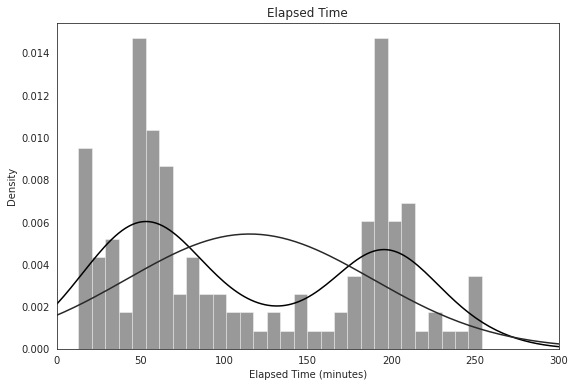

```python
sns.set_style("white")
sns.set_color_codes()

plt.figure(figsize=(9, 6))
plt.xlim(0, 300)

elapsed_time_distplot = sns.distplot(clean_df.elapsed_time, bins = 30, color='black', fit=norm)
elapsed_time_distplot.set_title('Elapsed Time')
elapsed_time_distplot.set_xlabel('Elapsed Time (minutes)')
```

The Elapsed Time plot shows that the data is not normally distributed. The Plot can be categorized as multimodal because it has 2 peaks and and it does not fit into the normal distribution line.

#### Distance

```
(0.0, 120.0)
```

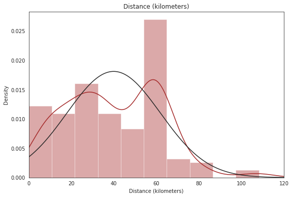

```python
plt.figure(figsize=(9, 6))

distance_distplot = sns.distplot(clean_df.distance, bins = 10, color='brown', fit=norm)
distance_distplot.set_title('Distance (kilometers)')
distance_distplot.set_xlabel('Distance (kilometers)')
plt.xlim(0, 120)
```

The Distance plot is similar to the Elapsed Time plot, it is not normally distributed because it has 2 peaks. The distributed data also doesn't fit to the ideal normal distribution line.

#### Average Speed

```
(0.0, 50.0)
```

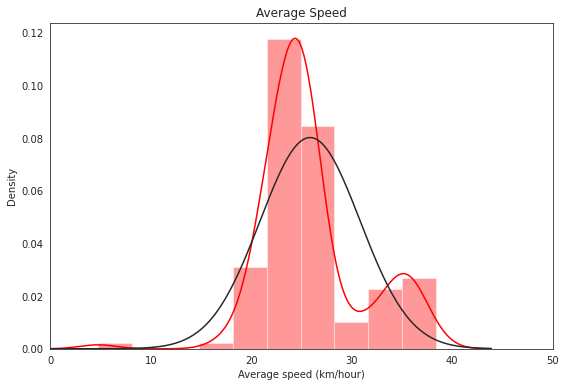

```python
plt.figure(figsize=(9, 6))

average_speed_distplot = sns.distplot(clean_df['Average Speed'], bins = 10, color='red', fit=norm)
average_speed_distplot.set_title('Average Speed')
average_speed_distplot.set_xlabel('Average speed (km/hour)')
plt.xlim(0, 50)
```

#### Average Watts

```
(100.0, 300.0)
```

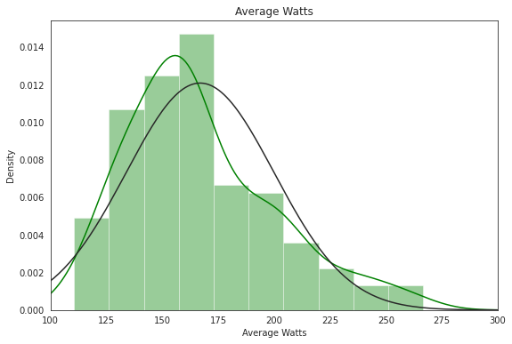

```python
plt.figure(figsize=(9, 6))

average_watts_distplot = sns.distplot(clean_df.average_watts, bins = 10, color='green', fit=norm)
average_watts_distplot.set_title('Average Watts')
average_watts_distplot.set_xlabel('Average Watts')
plt.xlim(100, 300)
```

Compared to the other plots, the average watts is the plot with the most normally distributed data. It almost fits the ideal normal distribution line perfectly. The plot shows positive skewness.

#### TSS

```
(0.0, 500.0)
```

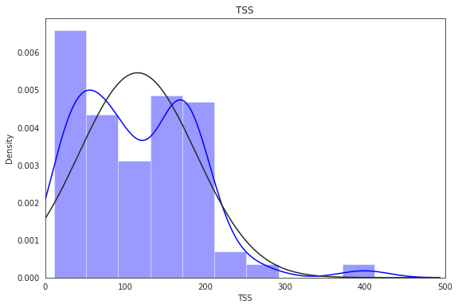

```python
plt.figure(figsize=(9, 6))

TSS_distplot = sns.distplot(clean_df.TSS, bins = 10, color='blue', fit=norm)
TSS_distplot.set_title('TSS')
TSS_distplot.set_xlabel('TSS')
plt.xlim(0, 500)
```

The TSS plot shows that it has 2 peaks and cannot be categorized as a normally distributed plot.

### Features Correlation Analysis

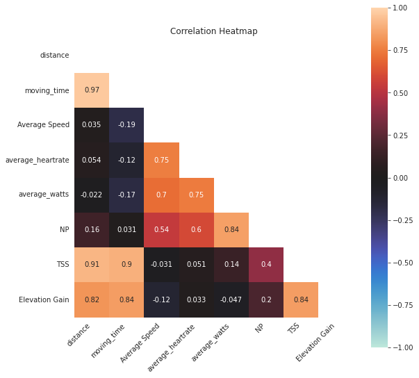

```python
# Creating the correlation dataframe
corr_df = clean_df[['distance', 'moving_time', 'Average Speed', 'average_heartrate', 'average_watts', 'NP', 'TSS', 'Elevation Gain']]
corr_df = corr_df.corr()

# Plotting the correlation dataframe
mask = np.triu(np.ones_like(corr_df, dtype=np.bool))

plt.figure(figsize=(9, 9))

corr_heatmap = sns.heatmap(corr_df,
                           mask=mask,
                           vmin = -1,
                           vmax=1,
                           center=0,
                           square=True,
                           annot=True)


corr_heatmap.set_xticklabels(corr_heatmap.get_xticklabels(),
                             rotation=45,
                             horizontalalignment='right')

corr_heatmap.set_title('Correlation Heatmap')
```

The heatmap plot of correlation shows the features that are highly correlated are moving_time and distance. This is pretty straightforward, longer cycling time leads to farther distance covered. The second pair of features that are highly correlated are TSS and distance followed by the TSS and moving_time pair. TSS stands for "Training Stress Score" and it is a measure of how hard a ride is. That is why distance and moving_time is highly correlated with TSS. If a rider ride very hard, he will cover a lot of distance and the moving time is going to be longer.

### Race vs Regular Ride Analysis

```
count    26.00
mean    259.95
std      19.43
min     231.61
25%     244.72
50%     257.29
75%     274.02
max     302.40
Name: NP, dtype: float64
```

```
count   113.00
mean    219.46
std      27.58
min     150.80
25%     203.37
50%     219.08
75%     232.82
max     294.31
Name: NP, dtype: float64
```

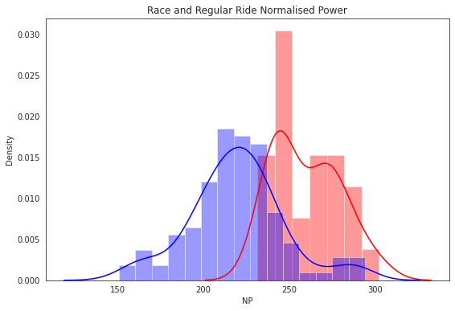

```python
race_df = clean_df[clean_df.workout_type=='Race']
ride_df = clean_df[clean_df.workout_type=='Ride']

display(race_df.NP.describe())
display(ride_df.NP.describe())

plt.figure(figsize=(9, 6))

race_distplot = sns.distplot(race_df.NP, bins = 7, color='red')
ride_distplot = sns.distplot(ride_df.NP, bins = 15, color='blue')

race_distplot.set_title('Race and Regular Ride Normalised Power')
```

It can be seen from the plot that distribution of Race Normalised Power data is relatively located to the right of Regular Ride Normalised Power data distribution. It means that the overall Normalised Power data distribution of Race is higher than the overall Regular Ride Normalised Power. The mean value and max value of NP from both Regular Ride and Race also shows that the Race's NP is higher thus it can be concluded that Race is more challenging than Regular Ride.

### Ride Summary

```python
# Creating and Cleaning Summary dataframe
dis_TSS_AvSpeed_kudos_df = pd.DataFrame(clean_df.resample('M').distance.sum())
dis_TSS_AvSpeed_kudos_df['TSS'] = clean_df.resample('M').TSS.sum()
dis_TSS_AvSpeed_kudos_df['Average Speed'] = clean_df.resample('M')['Average Speed'].mean()
dis_TSS_AvSpeed_kudos_df['kudos'] = clean_df.resample('M').kudos.sum()
dis_TSS_AvSpeed_kudos_df['Month Year'] = pd.to_datetime(dis_TSS_AvSpeed_kudos_df.index).to_period('M')
dis_TSS_AvSpeed_kudos_df = dis_TSS_AvSpeed_kudos_df.iloc[1:]

month_year_sr = pd.Series(['Feb 2018', 'Mar 2018', 'Apr 2018', 'May 2018', 'Jun 2018', 'Jul 2018',
                           'Aug 2018', 'Sep 2018', 'Oct 2018', 'Nov 2018', 'Des 2018', 'Jan 2019',
                           'Feb 2019', 'Mar 2019', 'Apr 2019', 'May 2019', 'Jun 2019', 'Jul 2019' ],
                           index=dis_TSS_AvSpeed_kudos_df.index)

dis_TSS_AvSpeed_kudos_df['month year'] = month_year_sr
dis_TSS_AvSpeed_kudos_df.set_index('month year', inplace=True)
dis_TSS_AvSpeed_kudos_df.drop(columns='Month Year', inplace=True)
display(dis_TSS_AvSpeed_kudos_df)
```

| month year | distance | TSS | Average Speed | kudos |
| --- | --- | --- | --- | --- |
| Feb 2018 | 343.10 | 1,035.47 | 25.22 | 108 |
| Mar 2018 | 456.50 | 1,345.64 | 25.73 | 148 |
| Apr 2018 | 423.60 | 1,232.15 | 24.41 | 129 |
| May 2018 | 174.90 | 483.59 | 22.49 | 54 |
| Jun 2018 | 193.40 | 586.49 | 27.04 | 64 |
| Jul 2018 | 180.70 | 381.43 | 23.51 | 50 |
| Aug 2018 | 65.90 | 242.42 | 25.81 | 20 |
| Sep 2018 | 184.80 | 627.21 | 26.44 | 68 |
| Oct 2018 | 194.30 | 554.95 | 24.79 | 63 |
| Nov 2018 | 480.60 | 1,287.13 | 24.73 | 155 |
| Des 2018 | 460.00 | 1,284.04 | 26.86 | 133 |
| Jan 2019 | 344.60 | 968.98 | 25.17 | 99 |
| Feb 2019 | 306.70 | 771.09 | 27.55 | 114 |
| Mar 2019 | 383.80 | 1,372.00 | 26.40 | 123 |
| Apr 2019 | 440.60 | 1,247.47 | 25.36 | 154 |
| May 2019 | 423.40 | 1,218.95 | 26.65 | 145 |
| Jun 2019 | 366.80 | 1,030.84 | 27.11 | 123 |
| Jul 2019 | 280.80 | 859.74 | 26.25 | 90 |

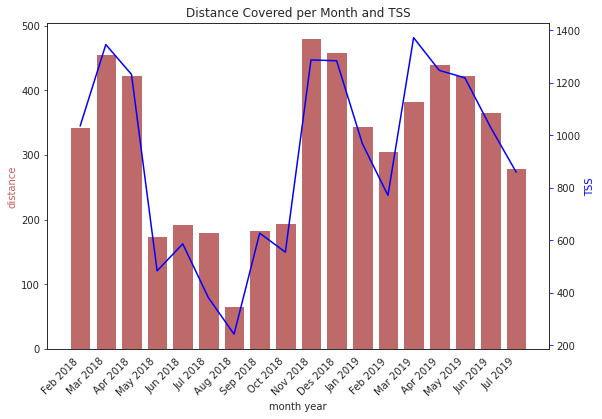

```python
# Plotting distance per month and TSS
fig, ax1 = plt.subplots(figsize=(9,6))
ax1.set_title('Distance Covered per Month and TSS')
ax1.set_xlabel('Month')
ax1.set_ylabel('Distance', color='indianred')
ax2 = sns.barplot(x=dis_TSS_AvSpeed_kudos_df.index, y='distance', data = dis_TSS_AvSpeed_kudos_df, color='indianred')
ax1.tick_params(axis='y')
ax2 = ax1.twinx()
ax2.set_ylabel('TSS', color='blue')
ax2 = sns.lineplot(x=dis_TSS_AvSpeed_kudos_df.index, y='TSS', data = dis_TSS_AvSpeed_kudos_df, sort=False, color='blue')
ax2.tick_params(axis='y', color='blue')
ax1.set_xticklabels(ax1.get_xticklabels(), rotation=45, horizontalalignment='right')
plt.show()
```

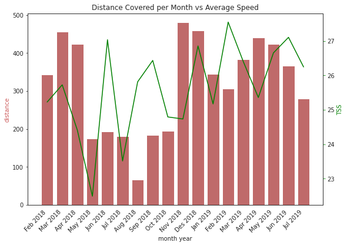

```python
# Plotting distance per mmonth and average speed
fig, ax1 = plt.subplots(figsize=(9,6))
ax1.set_title('Distance Covered per Month vs Average Speed')
ax1.set_xlabel('Month')
ax1.set_ylabel('Distance', color='indianred')
ax2 = sns.barplot(x=dis_TSS_AvSpeed_kudos_df.index, y='distance', data = dis_TSS_AvSpeed_kudos_df, color='indianred')
ax1.tick_params(axis='y')
ax2 = ax1.twinx()
ax2.set_ylabel('TSS', color='green')
ax2 = sns.lineplot(x=dis_TSS_AvSpeed_kudos_df.index, y='Average Speed', data = dis_TSS_AvSpeed_kudos_df, sort=False, color='green')
ax2.tick_params(axis='y', color='green')
ax1.set_xticklabels(ax1.get_xticklabels(), rotation=45, horizontalalignment='right')
plt.show()
```

```python
nov2018_distance = pd.DataFrame(clean_df.resample('D').distance.sum()).iloc[277:307]
nov2018_distance['date for plot'] = nov2018_distance.index.astype(str).str[:10]
display(nov2018_distance.sample(5))
```

| date | distance | date for plot |
| --- | --- | --- |
| 2018-11-07 00:00:00+11:00 | 0.00 | 2018-11-07 |
| 2018-11-19 00:00:00+11:00 | 0.00 | 2018-11-19 |
| 2018-11-12 00:00:00+11:00 | 0.00 | 2018-11-12 |
| 2018-11-29 00:00:00+11:00 | 0.00 | 2018-11-29 |
| 2018-11-22 00:00:00+11:00 | 0.00 | 2018-11-22 |

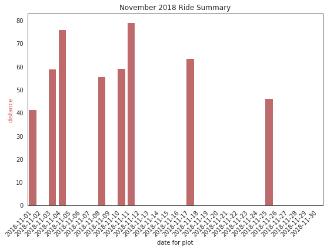

```python
fig, ax1 = plt.subplots(figsize=(9,6))
ax1.set_title('November 2018 Ride Summary')
ax1.set_xlabel('Month')
ax1.set_ylabel('Distance', color='indianred')
ax2 = sns.barplot(x=nov2018_distance['date for plot'], y=nov2018_distance.distance, color='indianred')
ax1.tick_params(axis='y')
ax1.set_xticklabels(ax1.get_xticklabels(), rotation=45, horizontalalignment='right')
plt.show()
```

November 2018 is the month with highest number of distance. Steve rode a lot in November 2018 and the chart shows Steve's daily ride distance. The chart shows the date with highest distance is 2018-11-11 and the date with lowest distance is 2018-11-01. The chart also shows that Steve rode more frequently in the first 2 week of November 2018 than the next 2 week of November 2018.

### What leads to more kudos?

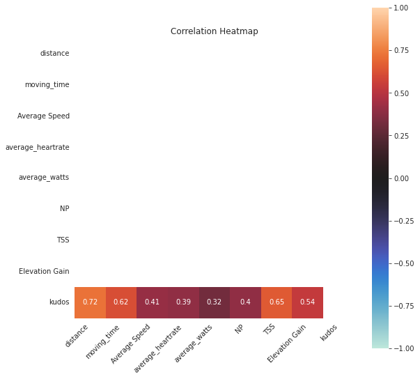

```python
# Creating the correlation dataframe
corr_df = clean_df[['distance', 'moving_time', 'Average Speed', 'average_heartrate', 'average_watts', 'NP', 'TSS', 'Elevation Gain', 'kudos']]
corr_df = corr_df.corr()

# Plotting the correlation dataframe
kudos_only_mask = np.array([[ True,  True,  True,  True,  True,  True,  True,  True,  True],
                            [True,  True,  True,  True,  True,  True,  True,  True,  True],
                            [True,  True,  True,  True,  True,  True,  True,  True,  True],
                            [True,  True,  True,  True,  True,  True,  True,  True,  True],
                            [True,  True,  True,  True,  True,  True,  True,  True,  True],
                            [True,  True,  True,  True,  True,  True,  True,  True,  True],
                            [True,  True,  True,  True,  True,  True,  True,  True,  True],
                            [True,  True,  True,  True,  True,  True,  True,  True,  True],
                            [False, False, False, False, False, False, False, False,  True]])

plt.figure(figsize=(9, 9))

corr_heatmap = sns.heatmap(corr_df,
                           mask=kudos_only_mask,
                           vmin = -1,
                           vmax=1,
                           center=0,
                           square=True,
                           annot=True)


corr_heatmap.set_xticklabels(corr_heatmap.get_xticklabels(),
                             rotation=45,
                             horizontalalignment='right')

corr_heatmap.set_title('Correlation Heatmap')
```

The correlation heatmap shows that feature that is most correlated with kudos is distance, followed by TSS.

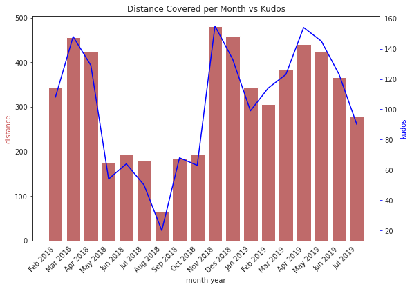

```python
# Plotting distance per mmonth and average speed
fig, ax1 = plt.subplots(figsize=(9,6))
ax1.set_title('Distance Covered per Month vs Kudos')
ax1.set_xlabel('Month')
ax1.set_ylabel('Distance', color='indianred')
ax2 = sns.barplot(x=dis_TSS_AvSpeed_kudos_df.index, y='distance', data = dis_TSS_AvSpeed_kudos_df, color='indianred')
ax1.tick_params(axis='y')
ax2 = ax1.twinx()
ax2.set_ylabel('kudos', color='blue')
ax2 = sns.lineplot(x=dis_TSS_AvSpeed_kudos_df.index, y='kudos', data = dis_TSS_AvSpeed_kudos_df, sort=False, color='blue')
ax2.tick_params(axis='y', color='blue')
ax1.set_xticklabels(ax1.get_xticklabels(), rotation=45, horizontalalignment='right')
plt.show()
```

The chart strengthen the point in kudos correlation heatmap analysis. Kudos is highly correlated with distance and it can be said that more distance leads to more kudos.

## Conclusion

There are several data science techniques that are applied in this project and they are data distribution, correlation and visualising summarised data. Five features are plotted using histogram and four of them dont't have ideal normal distribution shape, only one, which is 'Average Watts' feature, can be said to be normally distributed even though the shape is not perfect. Secondly, correlation analysis and visualising it using heatmap really helps in analysing features. One glance at the correlation heatmap immediately tells relationship among the features. Finally, summarising and visualising important features or data make it easy to understand the data. Trend, minimum values and other important aspects can be seen and understood easily if the data is presented using clear and concise visualisation